# lab 13

Author

Adelaide Cutler

```r
.libPaths(c("/home/ascutler_umass_edu/R/x86_64-pc-linux-gnu-library/4.5", "/usr/local/lib/R/site-library", "/usr/local/lib/R/library"))
```

```r
library(tidyverse)
library(janitor)
library(plotly)
library(DT)
library(lubridate)
```

# Step 1: Overall Data

```r
NEON_soilMAGs_soilChem <- read.csv("NEON_soilMAGs_soilChem.csv")
head(NEON_soilMAGs_soilChem)
```

```
  X         bin_oid          bin_id
1 1   3300075492_s0   3300075492_s0
2 2   3300075492_s1   3300075492_s1
3 3 3300075492_s100 3300075492_s100
4 4 3300075492_s106 3300075492_s106
5 5 3300075492_s108 3300075492_s108
6 6  3300075492_s11  3300075492_s11
                                                                                   site
1 University of Notre Dame Environmental Research Center NEON Field Site, Michigan, USA
2 University of Notre Dame Environmental Research Center NEON Field Site, Michigan, USA
3 University of Notre Dame Environmental Research Center NEON Field Site, Michigan, USA
4 University of Notre Dame Environmental Research Center NEON Field Site, Michigan, USA
5 University of Notre Dame Environmental Research Center NEON Field Site, Michigan, USA
6 University of Notre Dame Environmental Research Center NEON Field Site, Michigan, USA
          sample_name site_ID subplot layer quadrant     date img_genome_id
```

[output cut: 76 more lines]

# Step 2: Taxa distributions

For lab today I will be going over Bio-geography & Spatial Patterns within the above data set. These patterns look at the location in relationships with patterns. The below is mapped taxa distributions, which is the mapped abundance of different taxa in the data at certain locations.

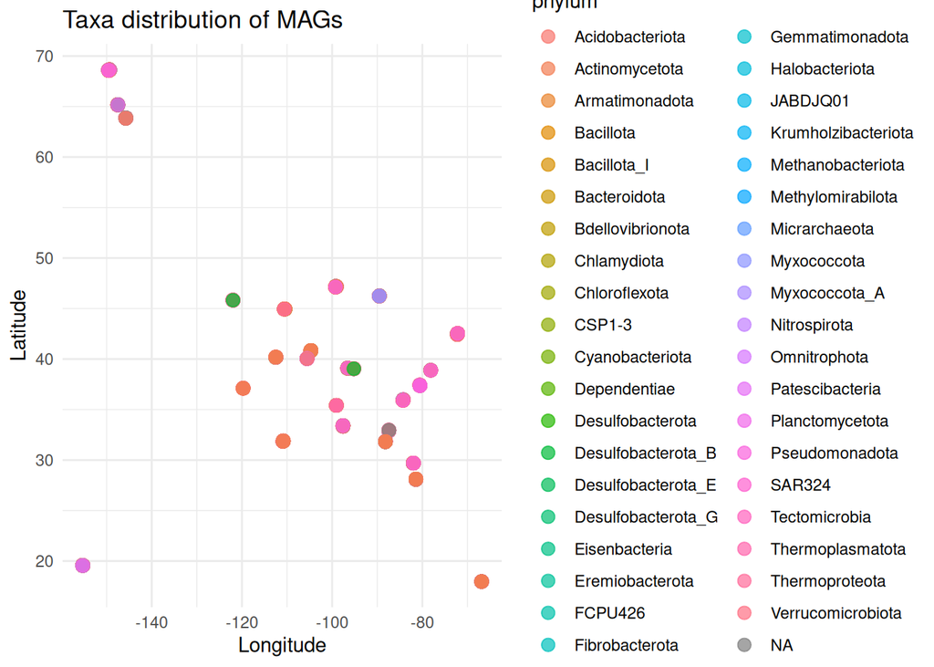

```r
ggplot(NEON_soilMAGs_soilChem, aes(x = decimalLongitude, y = decimalLatitude, color = phylum)) +
  geom_point(size = 3, alpha = 0.7) +
  labs(title = "Taxa distribution of MAGs",
       x = "Longitude", y = "Latitude") +
  theme_minimal()
```

Above is a spatial map of taxa by longitude and latitue and colored by type.

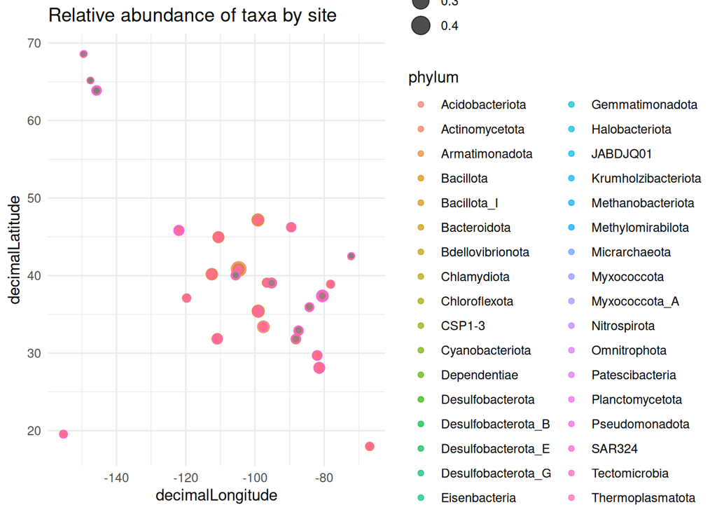

```r
taxa_by_site <- NEON_soilMAGs_soilChem %>%
  group_by(site_ID, phylum, decimalLatitude, decimalLongitude) %>%
  summarise(count = n(), .groups = "drop") %>%
  group_by(site_ID) %>%
  mutate(rel_abundance = count / sum(count))

ggplot(taxa_by_site, aes(x = decimalLongitude, y = decimalLatitude, size = rel_abundance, color = phylum)) +
  geom_point(alpha = 0.7) +
  labs(title = "Relative abundance of taxa by site") +
  theme_minimal()
```

This map is of abundance per site of each phylum.

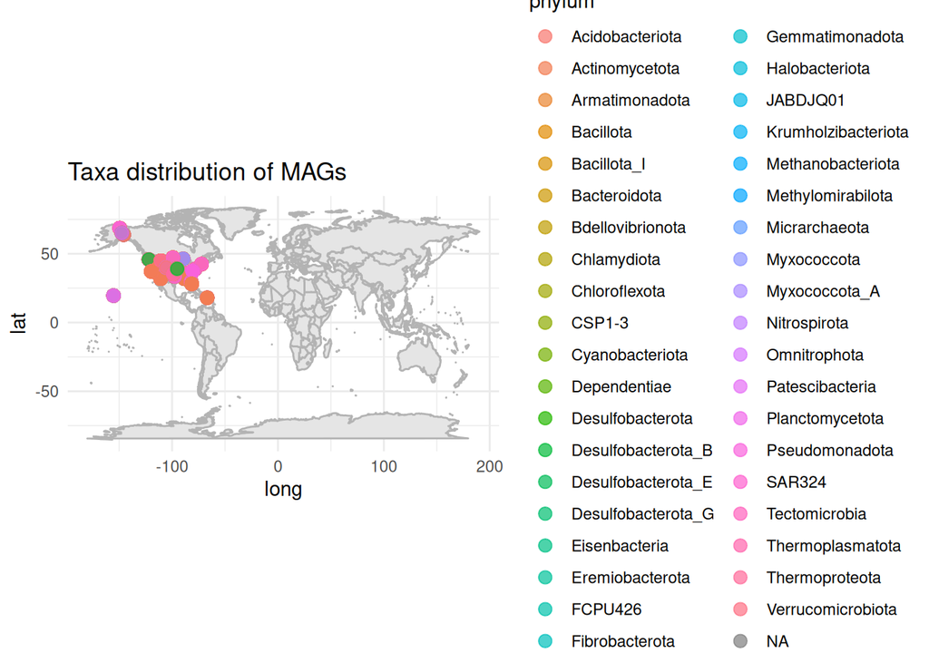

```r
library(maps)
world <- map_data("world")

ggplot() +
  geom_polygon(data = world, aes(x = long, y = lat, group = group),
               fill = "gray90", color = "gray70") +
  geom_point(data = NEON_soilMAGs_soilChem, aes(x = decimalLongitude, y = decimalLatitude, color = phylum),
             size = 3, alpha = 0.7) +
  coord_fixed(1.3) +
  labs(title = "Taxa distribution of MAGs") +
  theme_minimal()
```

This map shows the abundance on a real map of the world so theres a better idea of where everything is located for the reader.

# Step 3: Spatial autocorrelation

This will look to see if geography is associated to phylum communities.

```r
coords <- NEON_soilMAGs_soilChem %>%
  select(decimalLongitude, decimalLatitude) %>%
  filter(!is.na(decimalLongitude), !is.na(decimalLatitude))
mags_clean <- NEON_soilMAGs_soilChem %>%
  filter(!is.na(decimalLongitude), !is.na(decimalLatitude))

coords <- mags_clean %>% select(decimalLongitude, decimalLatitude)

library(spdep)
neighbors <- knearneigh(coords, k = 4)
nb <- knn2nb(neighbors)
listw <- nb2listw(nb)
```

The code above will define what counts as neighbors spatialy.

```r
mags_clean <- NEON_soilMAGs_soilChem %>% filter(!is.na(soilInWaterpH))
moran.test(mags_clean$soilInWaterpH, listw)
```

```
    Moran I test under randomisation

data:  mags_clean$soilInWaterpH
weights: listw

Moran I statistic standard deviate = 134.9, p-value < 2.2e-16
alternative hypothesis: greater
sample estimates:
Moran I statistic       Expectation          Variance
     9.909969e-01     -1.807338e-04      5.398492e-05
```

This result is a strong correlation meaning similar pH soil values tend to be near each other. This could mean the clustering shows there is an environmental reason behind the clusterings.

# Step 4: Distance-decay analysis

This will look at how the similarity of communities decreases as distance increases.

```r
comm_matrix <- NEON_soilMAGs_soilChem %>%
  group_by(site_ID, phylum) %>%
  summarise(count = n(), .groups = "drop") %>%
  pivot_wider(names_from = phylum, values_from = count, values_fill = 0)

# Extract coordinates
coords <- NEON_soilMAGs_soilChem %>%
  distinct(site_ID, decimalLatitude, decimalLongitude) %>%
  arrange(site_ID)
```

```r
library(vegan)
# Remove siteID column to get numeric matrix
dist_comm <- vegdist(comm_matrix[,-1], method = "bray")
```

The above code will Bray–Curtis dissimilarity, which is a statistical measure of dissimilarity.

```r
dist_geo <- dist(coords[,c("decimalLongitude","decimalLatitude")])
```

The above shows the distance between sites.

```r
comm_matrix <- NEON_soilMAGs_soilChem %>%
  group_by(site_ID, phylum) %>%
  summarise(count = n(), .groups = "drop") %>%
  pivot_wider(names_from = phylum, values_from = count, values_fill = 0)
coords <- NEON_soilMAGs_soilChem %>%
  distinct(site_ID, decimalLatitude, decimalLongitude) %>%
  arrange(site_ID)
site_data <- comm_matrix %>%
  inner_join(coords, by = "site_ID")
nrow(comm_matrix)
```

```
[1] 30
```

```r
nrow(coords)
```

```
[1] 251
```

```r
nrow(site_data)
```

```
[1] 251
```

```r
site_data_clean <- na.omit(site_data)
colSums(is.na(site_data_clean))
```

```
            site_ID     Acidobacteriota      Actinomycetota      Armatimonadota
                  0                   0                   0                   0
          Bacillota        Bacteroidota         Chlamydiota       Chloroflexota
                  0                   0                   0                   0
    Cyanobacteriota        Dependentiae    Desulfobacterota  Desulfobacterota_B
                  0                   0                   0                   0
    Eremiobacterota             FCPU426     Gemmatimonadota         Myxococcota
                  0                   0                   0                   0
       Nitrospirota     Patescibacteria     Planctomycetota      Pseudomonadota
                  0                   0                   0                   0
     Thermoproteota   Verrucomicrobiota                  NA   Methylomirabilota
                  0                   0                   0                   0
      Tectomicrobia       Eisenbacteria    Bdellovibrionota    Thermoplasmatota
                  0                   0                   0                   0
             CSP1-3       Myxococcota_A       Micrarchaeota        Omnitrophota
                  0                   0                   0                   0
        Bacillota_I              SAR324  Desulfobacterota_E  Desulfobacterota_G
                  0                   0                   0                   0
     Fibrobacterota      Halobacteriota Krumholzibacteriota   Methanobacteriota
                  0                   0                   0                   0
           JABDJQ01     decimalLatitude    decimalLongitude
                  0                   0                   0
```

```r
library(vegan)
comm_matrix <- site_data_clean %>%
  select(-site_ID, -decimalLatitude, -decimalLongitude)
dist_comm <- vegdist(comm_matrix, method = "bray")
coords <- site_data_clean %>% select(decimalLongitude, decimalLatitude)
dist_geo <- dist(coords)
mantel(dist_comm, dist_geo, method = "pearson")
```

```
Mantel statistic based on Pearson's product-moment correlation

Call:
mantel(xdis = dist_comm, ydis = dist_geo, method = "pearson")

Mantel statistic r: 0.4057
      Significance: 0.001

Upper quantiles of permutations (null model):
   90%    95%  97.5%    99%
0.0316 0.0398 0.0472 0.0580
Permutation: free
Number of permutations: 999
```

The above results for mantel show a moderately positive correlation between dissimilarity and distance with 0.4057 = r. The significance of p = 0.001 shows a high significance meaning the null hypothesis can be rejected and there is a correlation. Overall these results prove there is a relationship between geographical distance and dissimilarity.